# 《R语言》第10章：基础绘图

[返回课程主页](https://psychbruce.github.io/RCourse/)

授课教师：包寒吴霜

版权声明：本套课程材料开源，使用和分享必须遵守「创作共用许可协议 CC BY-NC-SA」（来源引用-非商业用途使用-以相同方式共享）。

# Chap10：基础绘图

#### 往期要点回顾

- [Chap09 # 回归模型建立与结果报告](https://psychbruce.github.io/RCourse/Chap09#%E5%9B%9E%E5%BD%92%E6%A8%A1%E5%9E%8B%E5%BB%BA%E7%AB%8B%E4%B8%8E%E7%BB%93%E6%9E%9C%E6%8A%A5%E5%91%8A)
- [Chap09 # 多个模型汇总与表格输出](https://psychbruce.github.io/RCourse/Chap09#%E5%A4%9A%E4%B8%AA%E6%A8%A1%E5%9E%8B%E6%B1%87%E6%80%BB%E4%B8%8E%E8%A1%A8%E6%A0%BC%E8%BE%93%E5%87%BA)

#### 本章要点目录

- 【探索发现】数据有了，图怎么画？
- 【知识点】ggplot2“搭积木”式绘图语法（重点）
- 【实践1】直方图
- 【实践2】密度图
- 【探索发现】颜色的RGB十六进制码
- 【知识点】箱线图的统计含义
- 【实践3】箱线图
- 【实践4】提琴图
- 【探索发现】山脊图
- 【实践5】柱形图（重点）
- 【实践6】点线图
- 【实践7】散点图（重点）
- 【实践8】气泡图
- 【探索发现】热力图
- 【实践9】折线图（重点）

```r
## 本章所需R包
library(bruceR)
# library(ggplot2)  # 加载bruceR时已默认加载ggplot2
```

# 数据可视化的总体思路

#### 【探索发现】数据有了，图怎么画？

- [R Graph Gallery R绘图美术馆](https://r-graph-gallery.com/)
  - 绘制变量分布
    - 直方图（Histogram）
    - 密度图（Density）
    - 箱线图（Boxplot）
    - 提琴图（Violin）
    - 山脊图（Ridgeline）
  - 绘制变量大小
    - 柱形图（Barplot）
    - 点线图（Dotted line）
  - 绘制变量关系
    - 散点图（Scatterplot）
    - 气泡图（Bubble）
    - 热力图（Heatmap）
  - 绘制变量趋势
    - 折线图（Line chart）
    - 面积图（Area chart）

#### 【知识点】ggplot2“搭积木”式绘图语法

`ggplot2`绘图语法的逻辑：

1. 准备数据（`data`），将变量映射到美学属性（`aes`），定义XY轴、颜色、大小等
2. 添加几何对象（`geom`），绘制点、线、面等，多个图层可通过加号依次叠加（`+`）
3. 可做分面小图（`facet`），调整标度（`scale`），投影到不同坐标系（`coord`）
4. 设置标题标签（`labs`），调整图例（`guides`），根据喜好选择主题方案（`theme`）

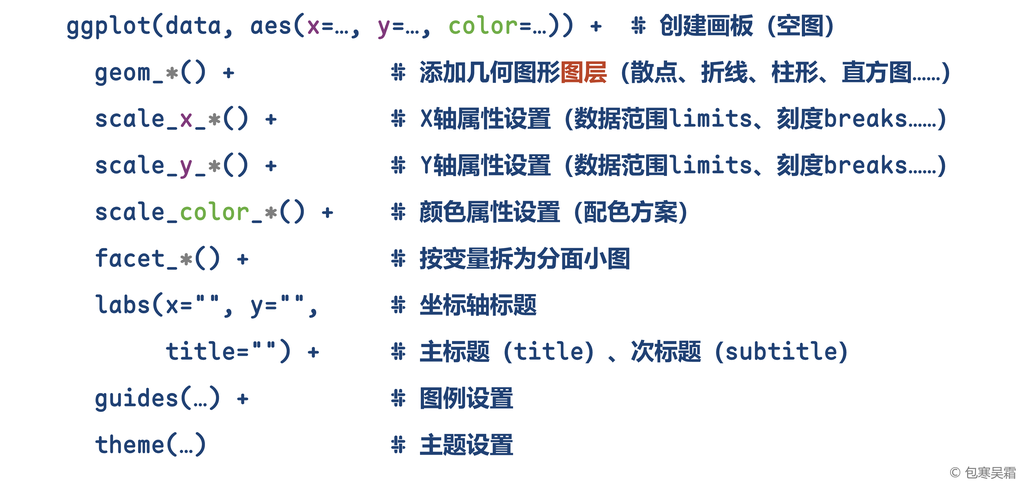

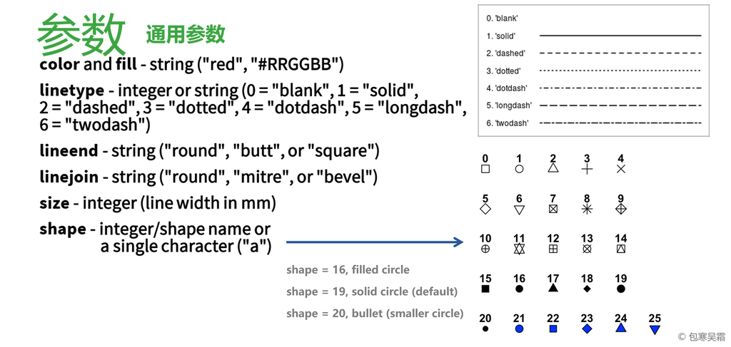

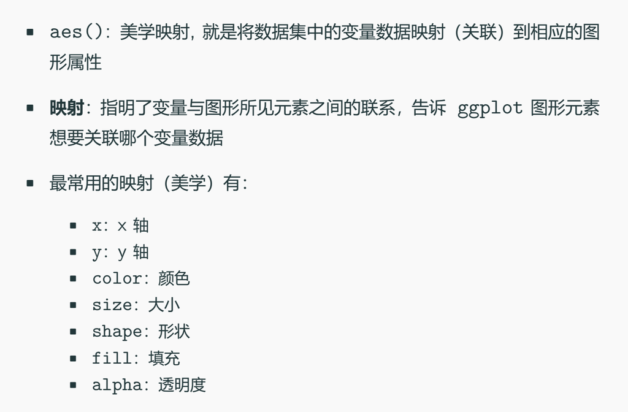

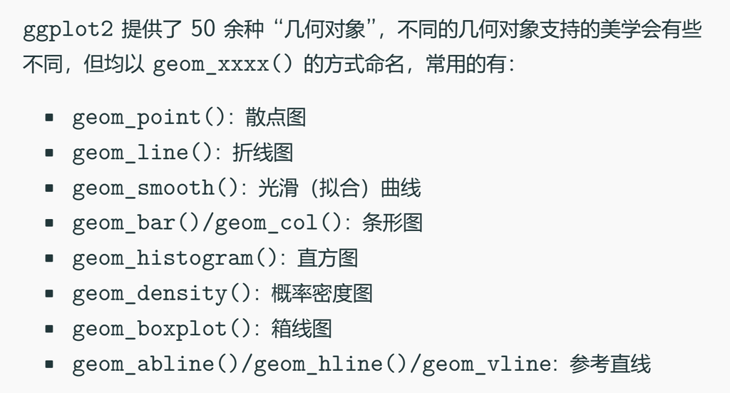

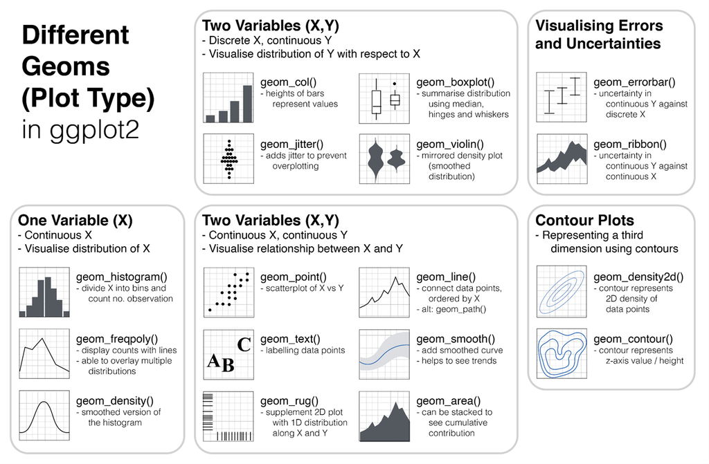

# 绘制变量分布

## 直方图

#### 【实践1】直方图

```r
## 数据准备
data = airquality
data$Month = as.factor(data$Month)
data$Temp.C = (data$Temp - 32) / 1.8  # 摄氏度 = (华氏度 - 32) / 1.8
str(data)
```

```
'data.frame':   153 obs. of  7 variables:
 $ Ozone  : int  41 36 12 18 NA 28 23 19 8 NA ...
 $ Solar.R: int  190 118 149 313 NA NA 299 99 19 194 ...
 $ Wind   : num  7.4 8 12.6 11.5 14.3 14.9 8.6 13.8 20.1 8.6 ...
 $ Temp   : int  67 72 74 62 56 66 65 59 61 69 ...
 $ Month  : Factor w/ 5 levels "5","6","7","8",..: 1 1 1 1 1 1 1 1 1 1 ...
 $ Day    : int  1 2 3 4 5 6 7 8 9 10 ...
 $ Temp.C : num  19.4 22.2 23.3 16.7 13.3 ...
```

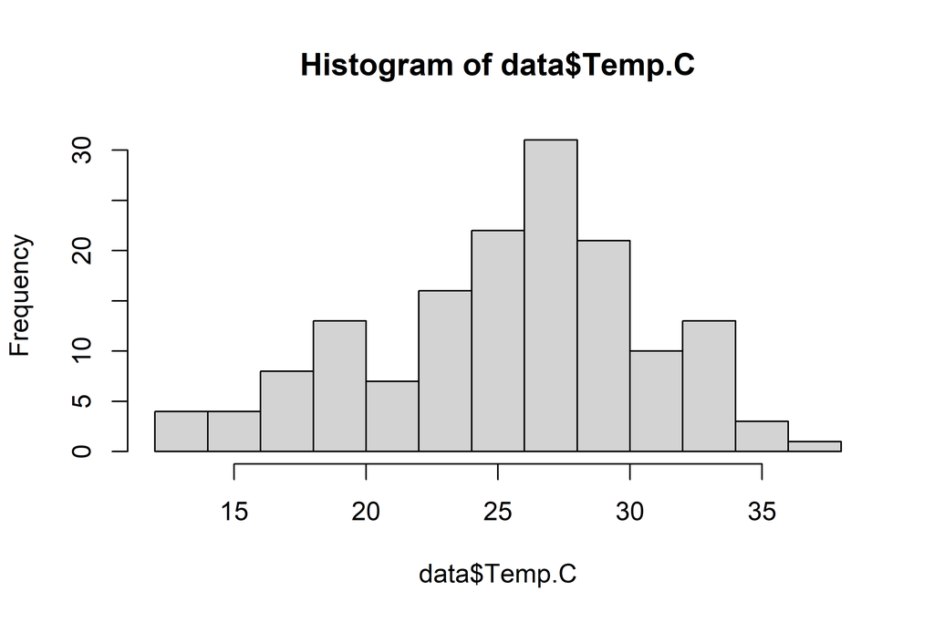

```r
## R基础作图函数：直方图
hist(data$Temp.C)
```

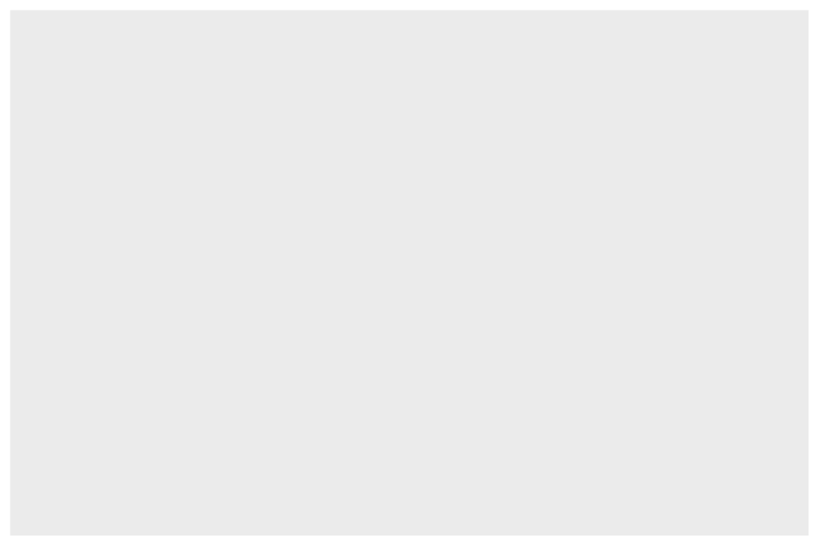

```r
## ggplot2搭积木作图
ggplot()  # 空画板
```

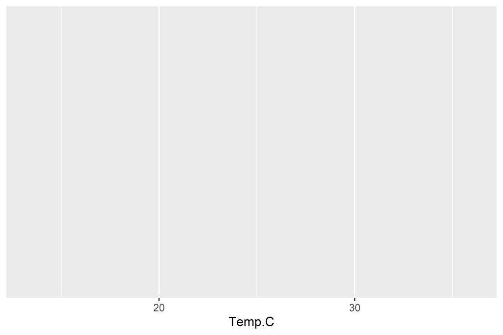

```r
ggplot(data, aes(x=Temp.C))  # 有了坐标系
```

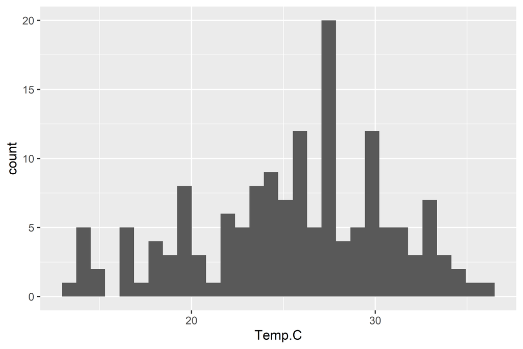

```r
ggplot(data, aes(x=Temp.C)) +
  geom_histogram()  # 直方图
```

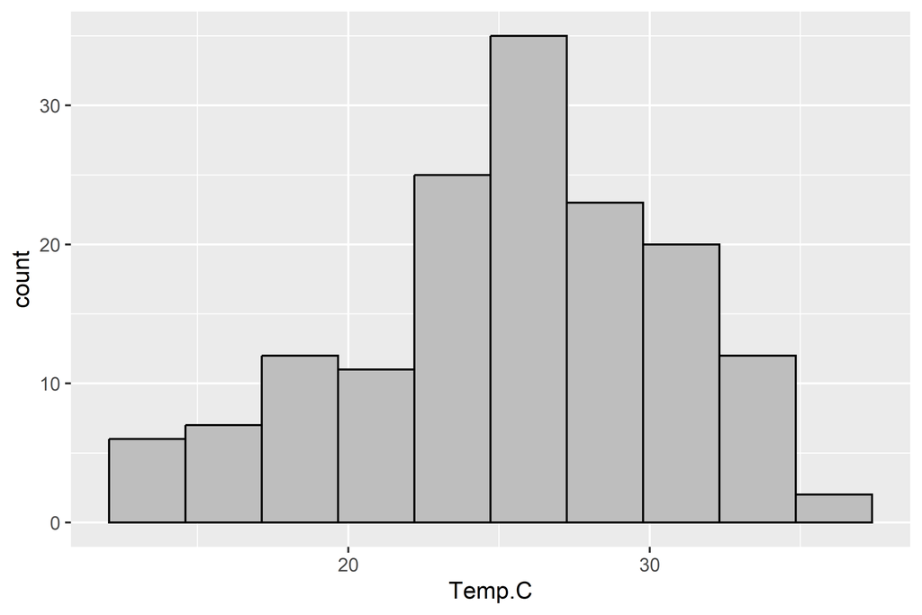

```r
ggplot(data, aes(x=Temp.C)) +
  geom_histogram(bins=10,
                 color="black",
                 fill="grey")
```

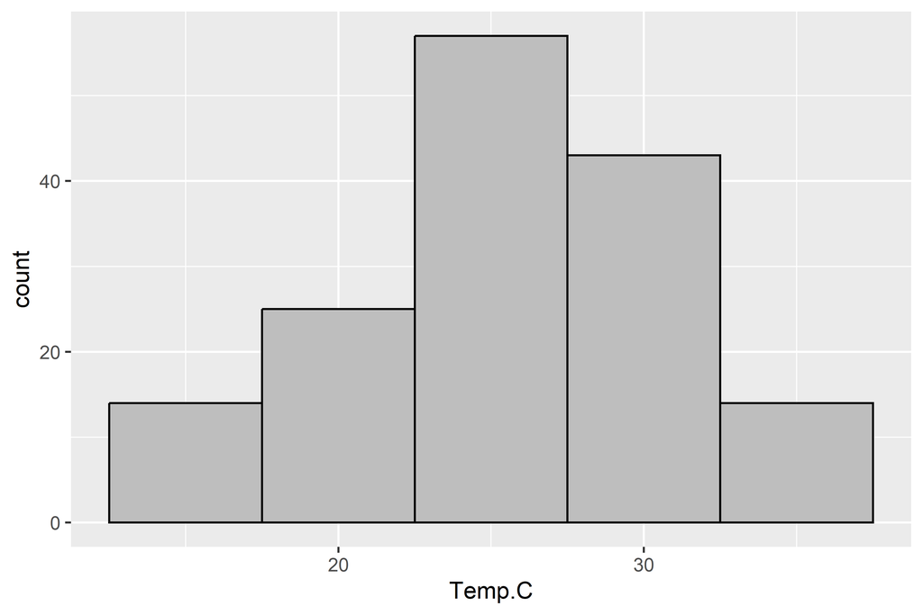

```r
ggplot(data, aes(x=Temp.C)) +
  geom_histogram(binwidth=5,
                 color="black",
                 fill="grey")
```

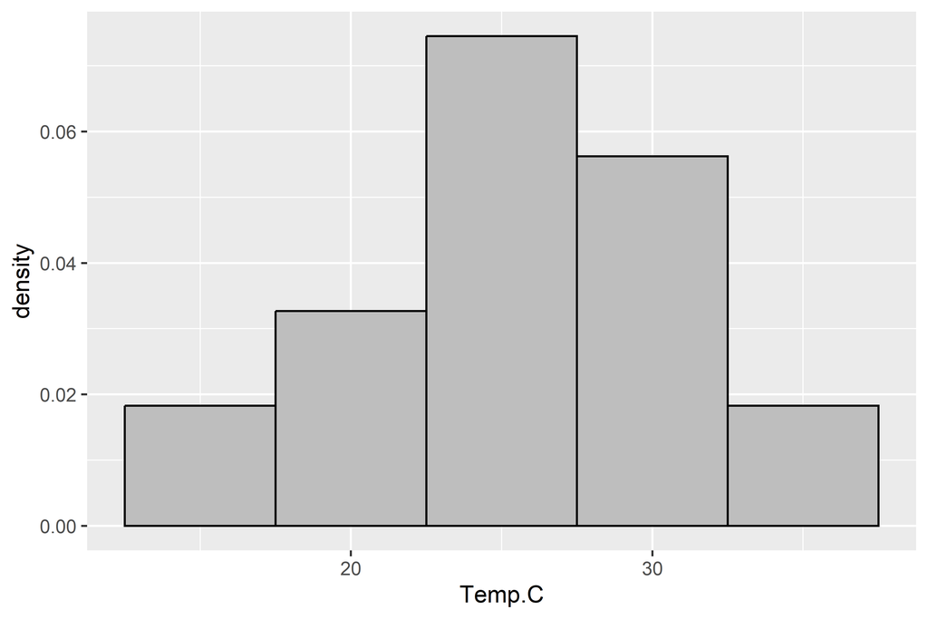

```r
ggplot(data, aes(x=Temp.C)) +
  geom_histogram(
    aes(y=after_stat(density)),
    ## density, integrate to 1
    binwidth=5,
    color="black",
    fill="grey")
```

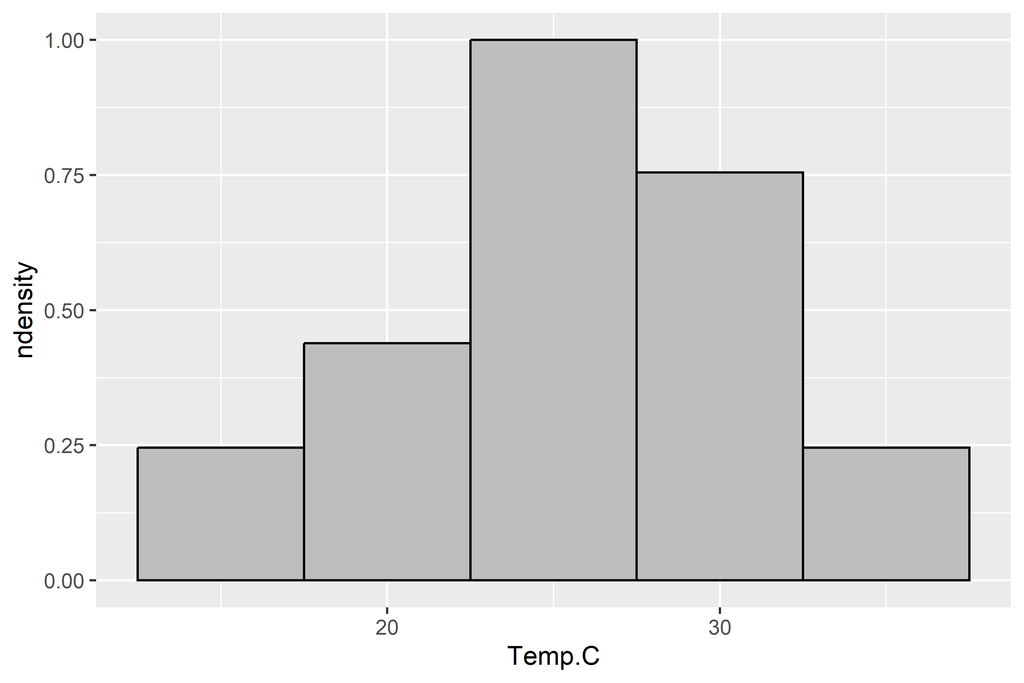

```r
ggplot(data, aes(x=Temp.C)) +
  geom_histogram(
    aes(y=after_stat(ndensity)),
    ## density, maximum to 1
    binwidth=5,
    color="black",
    fill="grey")
```

## 密度图

#### 【实践2】密度图

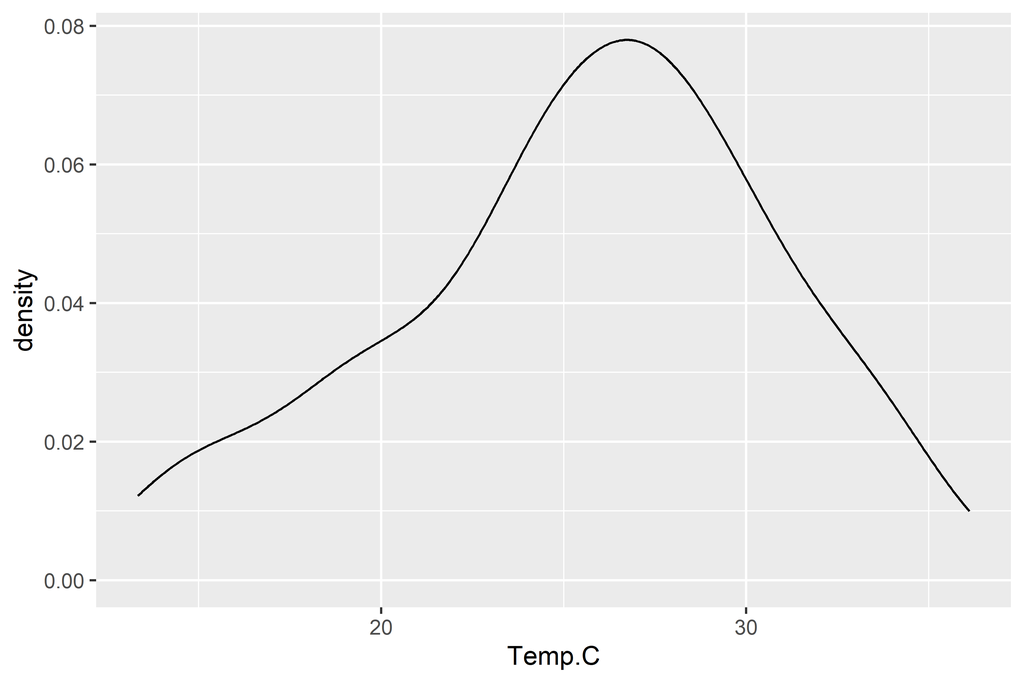

```r
ggplot(data, aes(x=Temp.C)) +
  geom_density()
```

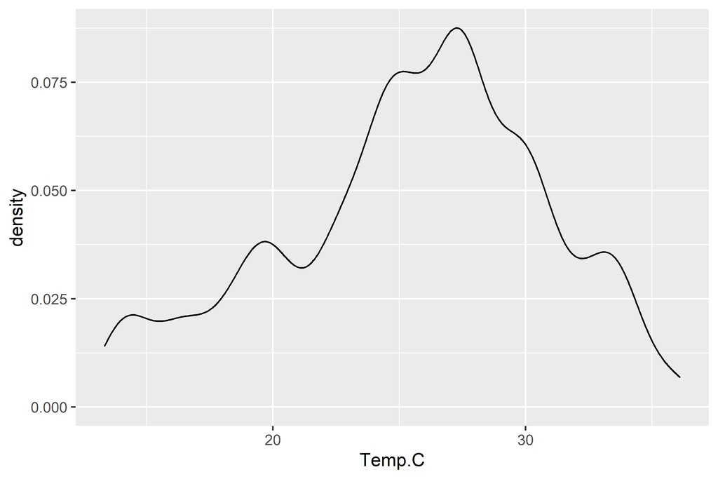

```r
ggplot(data, aes(x=Temp.C)) +
  geom_density(adjust=0.5)
```

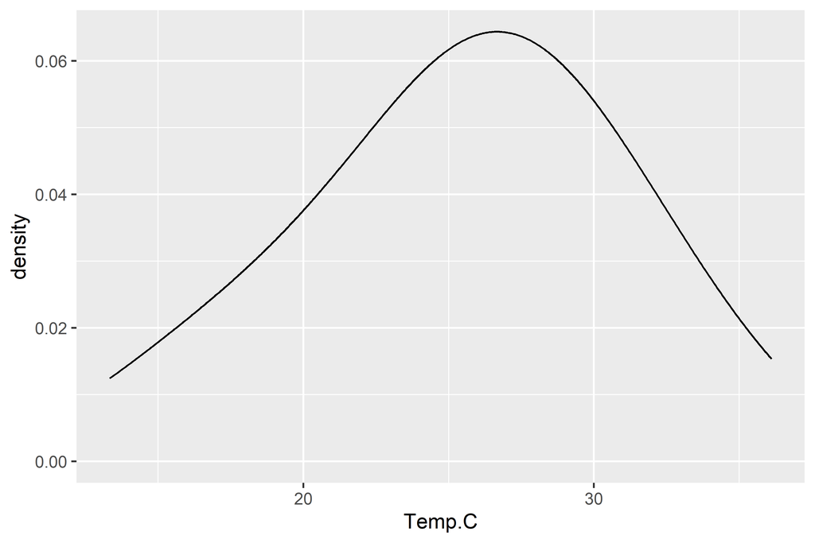

```r
ggplot(data, aes(x=Temp.C)) +
  geom_density(adjust=2)
```

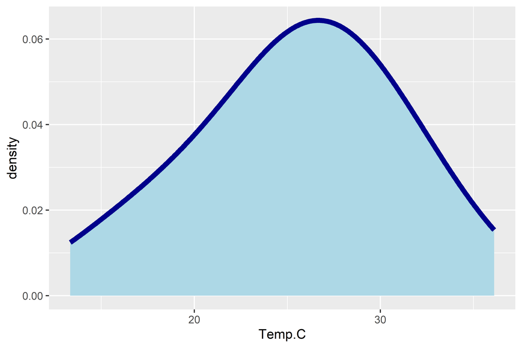

```r
ggplot(data, aes(x=Temp.C)) +
  geom_density(adjust=2,
               linewidth=2,
               color="darkblue",
               fill="lightblue")
```

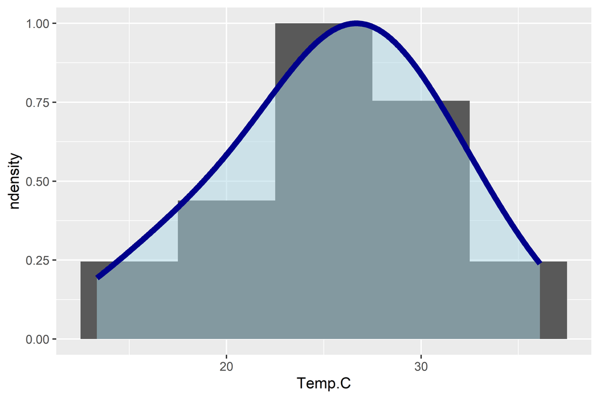

```r
ggplot(data, aes(x=Temp.C, y=after_stat(ndensity))) +
  geom_histogram(binwidth=5) +
  geom_density(adjust=2,
               linewidth=2,
               color="darkblue",
               fill="lightblue",
               alpha=0.5)
```

#### 【探索发现】颜色的RGB十六进制码

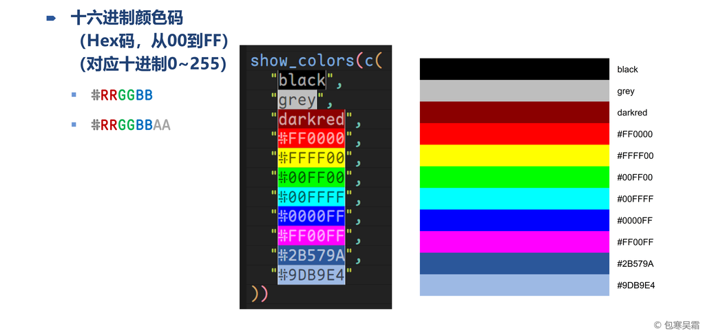

## 箱线图

#### 【知识点】箱线图的统计含义

- 四分位数（quartile）：把数据四等分的界限
  - Q1：0~25%（前25%界限）
  - Q2：25~50%（中位数50%界限）
  - Q3：50~75%（后25%界限）
  - Q4：75~100%（垫底）
- IQR（interquartile range）：四分位距（分布中Q1和Q3之间的变量值范围）
  - IQR = Q3 – Q1

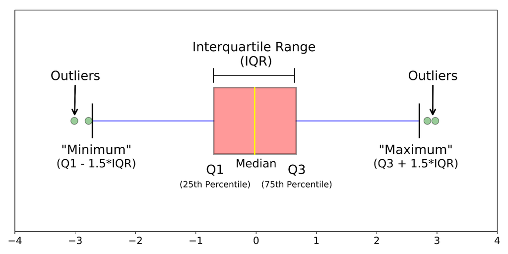

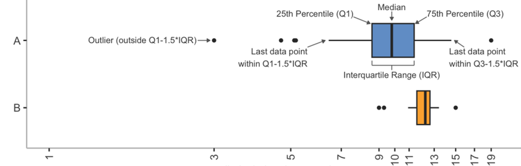

#### 【实践3】箱线图

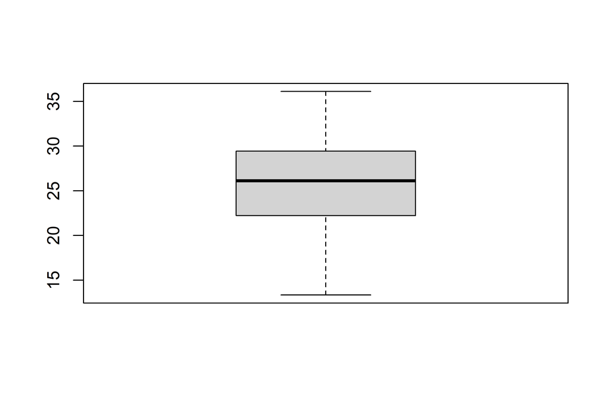

```r
## R基础作图函数：箱线图
boxplot(data$Temp.C)
```

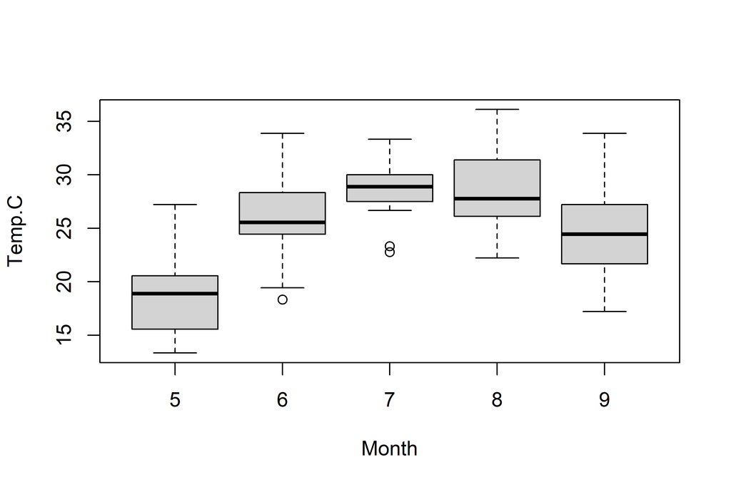

```r
boxplot(Temp.C ~ Month, data=data)
```

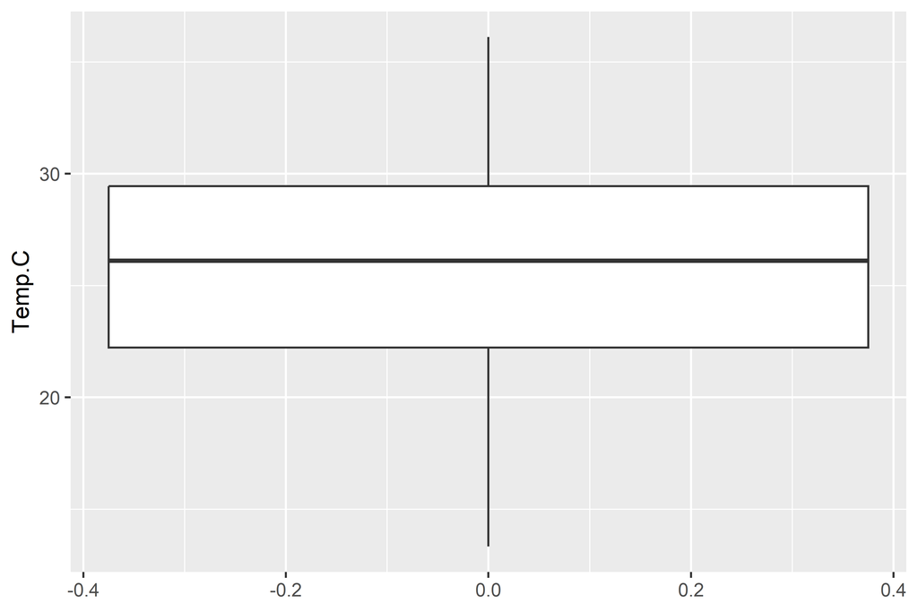

```r
## ggplot2搭积木作图
ggplot(data, aes(y=Temp.C)) +
  geom_boxplot()
```

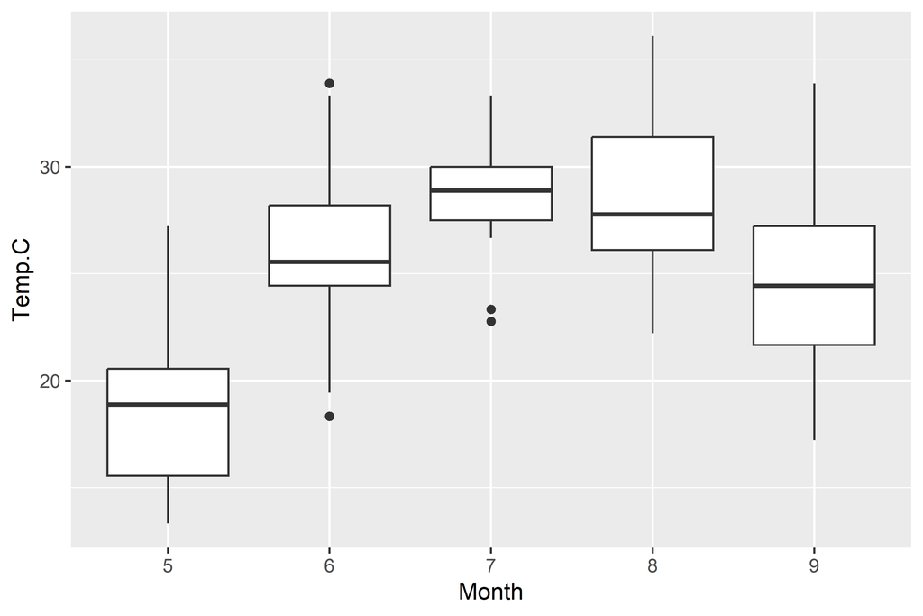

```r
ggplot(data, aes(x=Month, y=Temp.C)) +
  geom_boxplot()
```

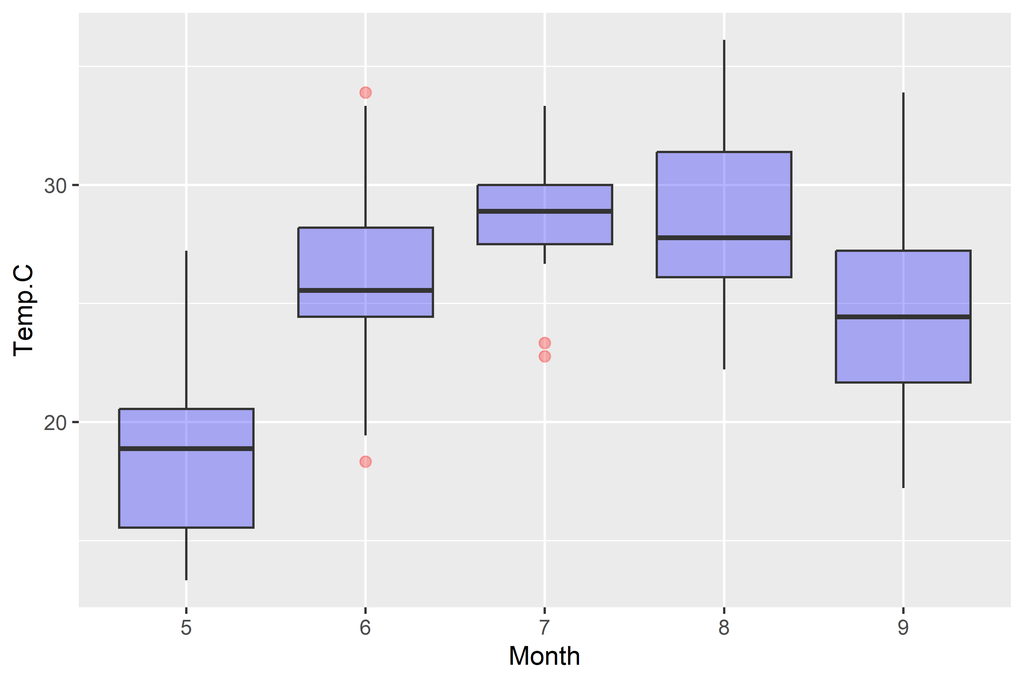

```r
ggplot(data, aes(x=Month, y=Temp.C)) +
  geom_boxplot(
    fill="blue",
    alpha=0.3,
    outlier.color="red",
    outlier.size=2)
```

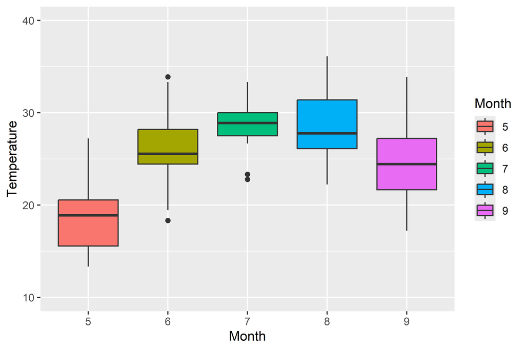

```r
ggplot(data, aes(x=Month, y=Temp.C)) +
  geom_boxplot(aes(fill=Month)) +
  scale_y_continuous(
    limits=c(10, 40)) +
  labs(x="Month",
       y="Temperature",
       fill="Month")
```

## 提琴图

#### 【实践4】提琴图

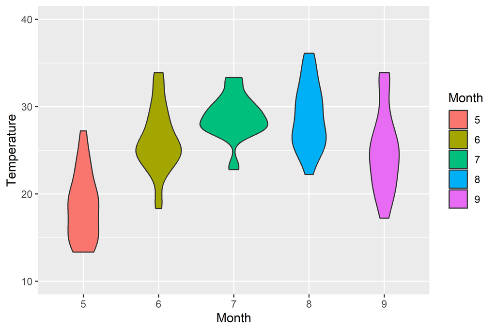

```r
ggplot(data, aes(x=Month, y=Temp.C)) +
  geom_violin(aes(fill=Month)) +
  scale_y_continuous(limits=c(10, 40)) +
  labs(x="Month",
       y="Temperature",
       fill="Month")
```

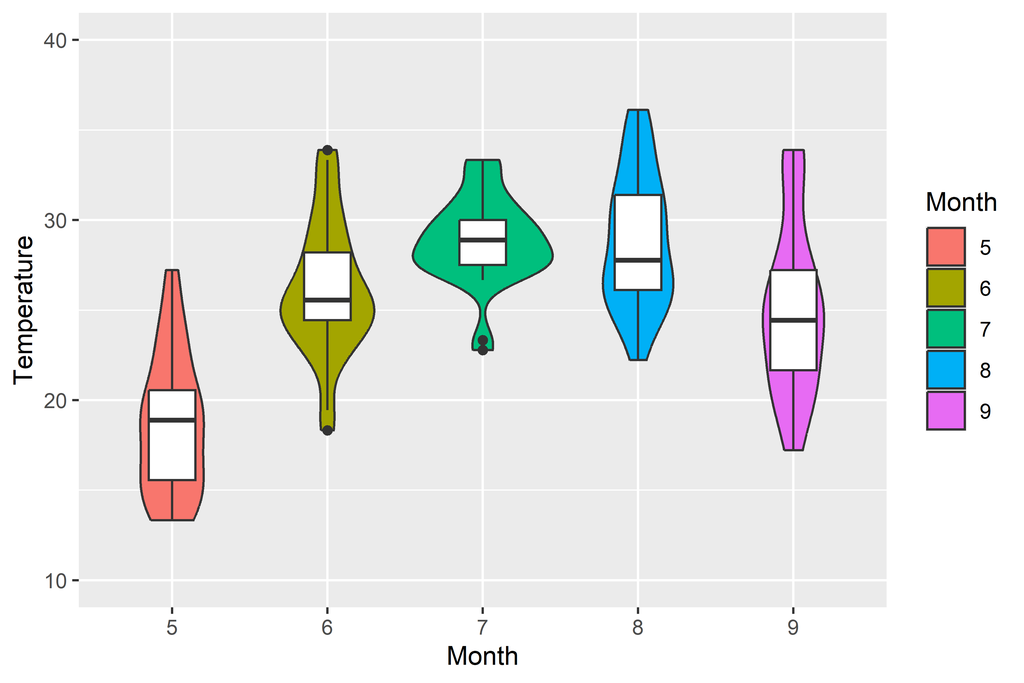

```r
ggplot(data, aes(x=Month, y=Temp.C)) +
  geom_violin(aes(fill=Month)) +
  geom_boxplot(fill="white", width=0.3) +
  scale_y_continuous(limits=c(10, 40)) +
  labs(x="Month",
       y="Temperature",
       fill="Month")
```